# Predicting Annual Fuel Costs and Analyzing the Impact of Vehicle Characteristics on Fuel Efficiency

STOR 320.002 Group 16

2026-04-27

# Introduction

The cost of owning a vehicle is far greater than the purchase price, with fuel expenses representing one of the most significant and unpredictable long-term costs. As gas prices fluctuate and environmental concerns continue to shape consumer behavior, understanding what drives fuel efficiency and annual fuel cost has become increasingly more important. Using the 2025 EPA Fuel Efficiency Dataset, which includes hundreds of vehicles across multiple manufacturers and classes, this analysis aims to find patterns in how different characteristics influence both fuel efficiency and cost.

This analysis focuses on two key research questions. First, are there a set of factors that can predict the average annual cost of fuel? Second, is there an association between transmission type and combined fuel efficiency? Predicting annual fuel cost requires using multiple vehicle features, making it a complex problem with real-world implications. At the same time, examining the relationship between transmission types and fuel efficiency may reveal trends about vehicle performance beyond what is commonly known.

The results of this analysis have meaningful implications for many people. Consumers can use these insights to make more informed purchasing decisions by understanding the underlying factors that drive fuel cost over time. Automakers can identify which features have the biggest effect on efficiency, helping guide future engineering decisions. Lawmakers may also benefit from a clearer understanding of how vehicle characteristics relate to fuel efficiency and vehicle emissions. Ultimately, this study highlights how analysis can provide valuable guidance in a market where cost and efficiency are greatly connected.

# Data

The data utilized in this study is sourced from the 2025 EPA Fuel Economy Guide, published by the U.S. Environmental Protection Agency (EPA). The original data is the product of the EPA’s annual rigorous and standardized vehicle testing program. By utilizing this official government data, we ensure that our analysis is based on verified and consistent measurements of the city, highway, and combined fuel economy across the current vehicle market.

Each observation in this dataset represents a specific vehicle configuration, defined as a unique combination of manufacturer, engine size, transmission, and drive type. Our cleaned dataset consists of 868 observations, representing a robust cross-section of 23 manufacturers and 20 distinct vehicle classes. This allows us to isolate the effects of specific components, such as comparing the efficiency of a 4-cylinder engine against a 6-cylinder engine, while controlling for other vehicle characteristics.

Summary Statistics for Key Quantitative Variables

Fuel economy, engine displacement, and fuel cost across all 2025 vehicles

| Variable | Minimum | Mean | Maximum | Std. Dev |
| --- | --- | --- | --- | --- |
| engine_displacement | 1.2 | 3.0 | 8.0 | 1.2 |
| comb_fe | 9.0 | 23.9 | 57.0 | 7.0 |
| annual_fuel_cost | 900.0 | 2,641.6 | 7,100.0 | 783.9 |

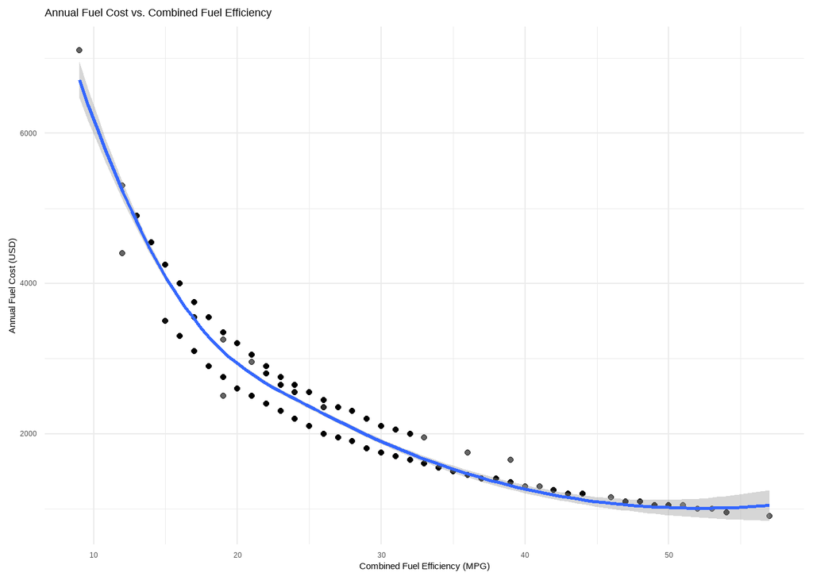

These variables function as the primary levers of our analysis. Our dependent variable, `annual_fuel_cost`, serves as the proxy for the financial impact of vehicle ownership, while our independent variables are categorized into two groups, physical and technological configurations. Engine displacement and cylinder count act as proxies for the vehicle’s raw power and potential energy demand, while categorical features like transmission type and air aspiration represent the modern, efficiency focused design choices intended to optimize performance. By examining these factors in tandem, we can differentiate between the baseline costs inherent to a vehicle’s size and the additional variations attributed to its specific engineering.

Beyond those specific variables, this dataset is uniquely suited to address our research questions regarding fuel cost prediction and transmission efficiency. Because the dataset includes a diverse range of vehicle classes, spanning from high efficiency subcompacts to heavy duty trucks, we are able to observe the impact of design choices across a broad spectrum of real world use cases. This diversity ensures that when we evaluate features like transmission types or engine configurations, our findings reflect genuine performance trends across the automotive market.

Finally, our initial Exploratory Data Analysis (EDA) revealed that while the data is largely complete, certain variables required cleaning to maintain model integrity. Specifically, we identified variables such as `max_biodiesel_percent` which contained missing values for over 97% of the dataset. To prevent these sparse features from introducing bias or noise into our models, they were excluded from the analysis. This cleaning process ensures that our final dataset is robust and focused solely on variables that provide meaningful insights into the drivers of vehicle fuel efficiency.

# Results

To address our first research question — whether vehicle characteristics can predict annual fuel cost — we constructed a correlation matrix to identify the strongest numeric predictors and fitted both a simple linear regression and a multiple linear regression model. To address our second research question — whether transmission type is associated with combined fuel efficiency — we created side-by-side boxplots to visualize distributional differences across transmission types and conducted a one-way ANOVA test to determine whether those differences are statistically significant.

We chose to use a correlation matrix of factors affecting fuel cost. This matrix shows that there is a strong negative association between the different types of fuel efficiency and annual fuel cost. This means that if a vehicle has a higher fuel efficiency (city, highway, or combined), it will likely have a lower annual fuel cost and we can use this factor to predict what the annual fuel cost of other vehicles may be. This correlation matrix also shows that higher engine displacement (size) and number of cylinders will lead to higher annual fuel cost.

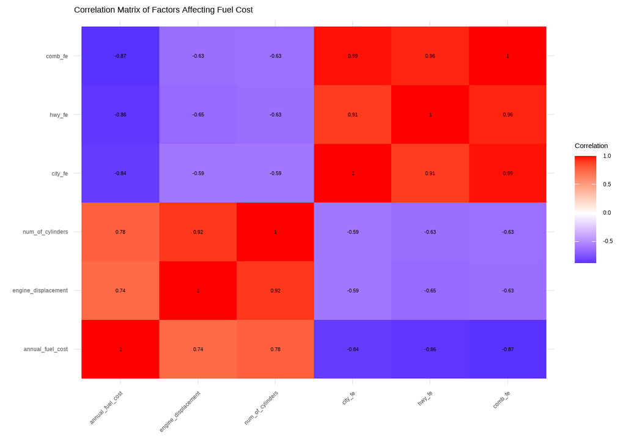

To investigate the association between transmission types and combined fuel efficiency, we first created a set of side-by-side boxplots which allow us to see the difference in medians and IQR across each transmission type.

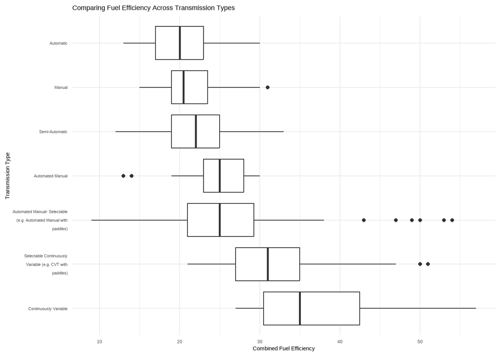

We also created a linear regression line that shows that as engine size increases, so does the annual fuel cost for vehicles in this dataset. This is not surprising because we would assume that the larger the engine, the more fuel it requires to run and therefore the more expensive it would be to own.

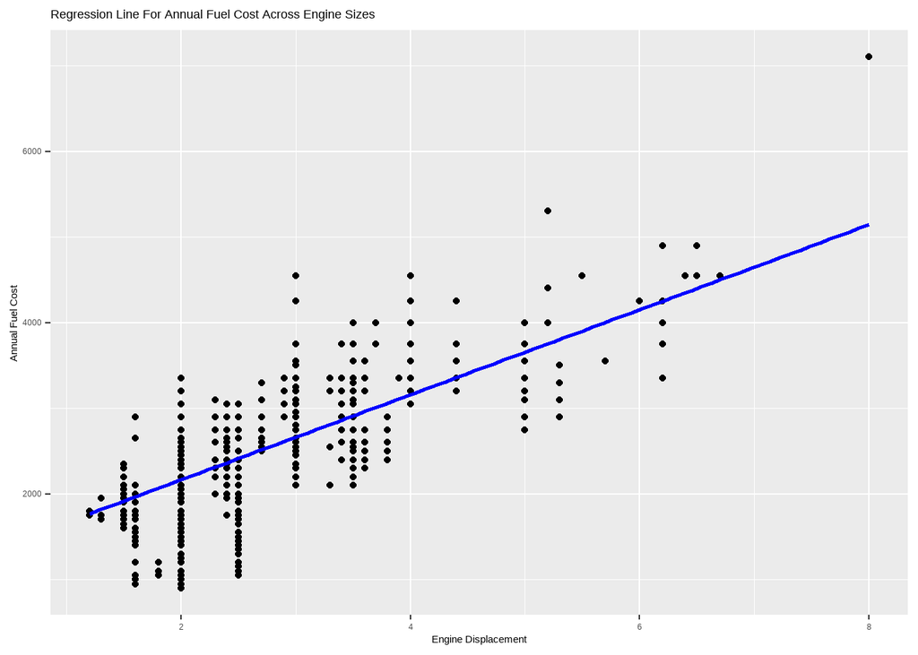

Lastly, we completed an ANOVA test which compares a categorical variable with multiple groups across a numeric variable. In this case we were evaluating the combined fuel efficiency across transmission types. The output resulted in a very small p-value (much smaller than 0.05) so we will reject the null hypothesis that there is no difference in combined fuel efficiency across transmission types and do have evidence that the type of transmission of the vehicle does impact the combined fuel efficiency of the vehicles.

Association between Transmission Type and Combined Fuel Efficiency

ANOVA results. A small p-value indicates significant differences among transmission types.

| Transmission Type | DF | Sum Sq | Mean Sq | F value | p-value |
| --- | --- | --- | --- | --- | --- |
| trans_description | 6 | 18,552.50 | 3,092.08 | 111.48 | 0.0000 |
| Residuals | 861 | 23,880.53 | 27.74 | NA | NA |

Blue cells indicate statistically significant (p < 0.05).

To better understand how multiple vehicle characteristics jointly influence annual fuel cost, we constructed a multiple linear regression model including combined fuel efficiency, engine cylinder count, drivetrain type, and a simplified vehicle class variable. This model allows us to isolate the effect of each factor while controlling for the others. The results show that combined fuel efficiency is the greatest predictor of annual fuel cost, with higher MPG values significantly reducing expected fuel expenditures. Additionally, vehicles with more cylinders and more complex drivetypes such as all-wheel drive and four-wheel drive are associated with higher fuel costs. Vehicle class also plays a role, with performance-oriented vehicles and vans showing a distinct cost pattern when compared to passenger vehicles. Overall, the model explains a substantial proportion, about 87%, of the variation in annual fuel cost, indicating that these factors provide a strong basis for predicting fuel expenses.

Multiple Linear Regression Model Fit

Predicting annual fuel cost using combined FE, cylinders, drivetrain, and vehicle class

| R^2 | Adjusted R^2 | Residual Std. Error | F-statistic | Model p-value | Num DF | Denom DF |
| --- | --- | --- | --- | --- | --- | --- |
| 0.877 | 0.876 | 276.219 | 556.996 | 0.0000 | 11.000 | 856.000 |

Multiple Linear Regression Coefficients

Factors associated with annual fuel cost.

| Predictor | Estimate | Std. Error | t value | p-value |
| --- | --- | --- | --- | --- |
| (Intercept) | 3,447.09 | 96.02 | 35.90 | 0.0000 |
| comb_fe | −73.13 | 2.00 | −36.58 | 0.0000 |
| num_of_cylinders | 160.04 | 7.22 | 22.17 | 0.0000 |
| drive_desc2-Wheel Drive, Rear | −26.07 | 36.80 | −0.71 | 0.4789 |
| drive_desc4-Wheel Drive | 148.54 | 39.32 | 3.78 | 0.0002 |
| drive_descAll Wheel Drive | 125.39 | 29.35 | 4.27 | 0.0000 |
| drive_descPart-time 4-Wheel Drive | 12.07 | 50.63 | 0.24 | 0.8117 |
| carline_class_descPassenger Car | 100.33 | 53.89 | 1.86 | 0.0630 |
| carline_class_descPerformance/Small | 352.75 | 63.21 | 5.58 | 0.0000 |
| carline_class_descPickup Truck | −154.72 | 60.89 | −2.54 | 0.0112 |
| carline_class_descSUV/Crossover | −29.56 | 52.68 | −0.56 | 0.5748 |
| carline_class_descVan/Minivan | −283.72 | 110.59 | −2.57 | 0.0105 |

Blue cells indicate statistically significant predictors (p < 0.05)

Finally, to validate these findings, we implemented a Random Forest model to assess the importance of each predictor in determining annual fuel cost. The results confirm that combined fuel efficiency is the most valuable predictor, followed by the number of cylinders and drivetrain type, with vehicle class having a lesser impact. These findings are consistent with our regression results and reinforce the conclusion that fundamentals like fuel efficiency and engine size are the primary drivers of fuel cost, while categorical distinctions like transmission type or vehicle class play a secondary role.

To further evaluate predictive performance, we benchmarked seven models — OLS, Elastic Net, Quantile Regression, Bayesian Regression, Decision Tree, Random Forest, and XGBoost — using 5-fold cross-validation. Models were compared on RMSE, MAE, R-squared, and MAPE. The results, shown in the table below, demonstrate that tree-based ensemble methods substantially outperform linear alternatives. XGBoost achieved the lowest RMSE (183.48) and highest R-squared (0.9425), followed closely by Random Forest (RMSE = 184.86, R-squared = 0.9417). Linear models including OLS and Elastic Net plateaued around an R-squared of 0.879, indicating that the relationship between vehicle characteristics and annual fuel cost contains nonlinear structure that regression alone cannot fully capture. Bayesian Regression performed notably worse across all metrics, likely due to its sensitivity to prior specification in this context.

**Final Model Scorecard**

*Ranked by RMSE (lowest to highest)*

| Model | RMSE ↓ | MAE ↓ | R-squared ↑ | MAPE (%) ↓ |
| --- | --- | --- | --- | --- |
| XGBoost | 183.4834 | 133.4891 | 0.9425 | 5.1639 |
| Random Forest | 184.8616 | 122.8410 | 0.9417 | 4.7618 |
| Decision Tree | 193.0693 | 140.1743 | 0.9366 | 5.5851 |
| Elastic Net | 266.4164 | 209.2647 | 0.8794 | 8.7503 |
| OLS | 266.5860 | 209.2748 | 0.8797 | 8.8100 |
| Quantile Regression (Median) | 278.9104 | 203.6260 | 0.8732 | 9.1003 |
| Bayesian Regression | 1964.7117 | 1897.1809 | 0.7866 | 74.0929 |

Random Forest Variable Importance

Increase in MSE and Node Purity when each variable is permuted

| Variable | % Increase in MSE | Increase in Node Purity |
| --- | --- | --- |
| comb_fe | 44.18 | 243,568,958.59 |
| num_of_cylinders | 28.87 | 121,270,364.57 |
| drive_desc | 30.32 | 58,407,117.53 |
| carline_class_desc | 25.54 | 20,436,035.65 |

Blue cells indicate the most important variable for that metric.

# Conclusion

Overall, our findings were largely consistent with expectations while also revealing several meaningful patterns in how vehicle characteristics influence fuel cost and efficiency. As expected, fuel efficiency and engine-related variables like engine displacement and number of cylinders showed strong relationships with annual fuel cost. Vehicles with better fuel efficiency exhibited lower fuel costs, while larger engines were associated with higher fuel costs. However, it was more surprising to see that drivetrain type and vehicle class were also significant predictors, suggesting that broader design choices can still contribute to fuel cost.

These results have clear implications for consumers and manufacturers. For consumers, they emphasize that long-term fuel cost is driven primarily by fundamental features rather than surface-level features or manufacturer marketing claims. In particular, paying attention to fuel efficiency, engine size, and drivetrain can lead to more cost-effective decisions when purchasing a new car. For manufacturers, the results highlight the importance of optimizing basic components, as improvements in fuel efficiency have a significant impact on reducing ownership costs.

In terms of our methodology, our multiple linear regression model provided strong explanatory power and interpretability, and tree-based ensemble methods like XGBoost and Random Forest demonstrated that nonlinear relationships in the data can be captured to meaningfully improve predictive accuracy. One avenue for further improvement would be the addition of interaction terms in the regression models, which may deepen our understanding of how certain features behave differently across vehicle categories. Stacking or blending ensemble approaches could also be explored to combine the interpretability of linear models with the predictive strength of tree-based methods.

Finally, the scope of this analysis was limited by the availability of certain information. While the dataset included key engine and classification features, it lacks important measures like vehicle weight, which could significantly influence fuel consumption. The dataset also only includes vehicles in the 2025 model year, whereas a dataset with multiple years would better explain trends in how fuel efficiency and fuel cost have changed over time and how they will change in the future. Access to this information would likely improve model accuracy and provide a more complete representation of the features that determine annual fuel cost.